# People on the bus during different reasons of travel

## What’s going on with this data?

This data set represents my observations from my daily bus commute. I take the bus for different reasons, so I decided to use that as the categorical data and the number of people I count on the bus right before I get off as the numerical data.

The reasons for my travel would be for

- Work
- University
- To meet friends
- Errands

## Average number of people on the bus by month

This is a bar chart that shows the average number of people on the bus by month.

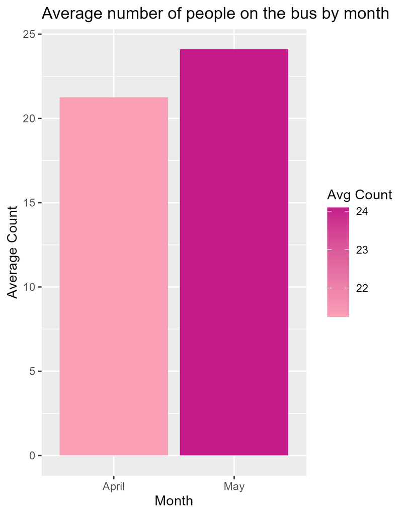

the darker the bar is, the higher the average count will be

## Total number of bus entries submitted each month grouped by reason of travel

This stacked bar chart shows the number of entries I made per month. The different reasons of travel is also included as distinct sections within each bar.

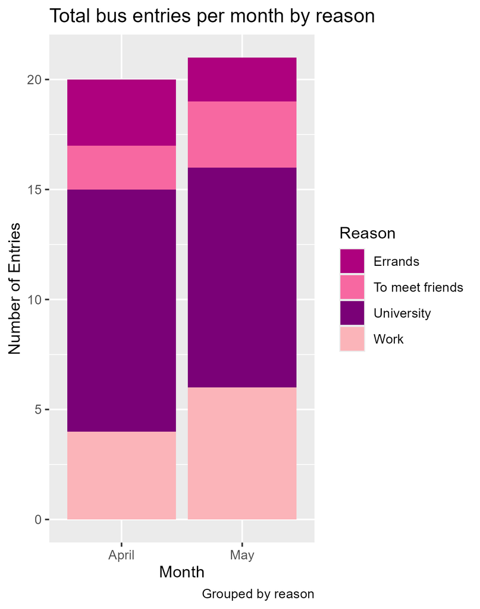

different reasons are represented by different sections of the bar

## Distribution of people on the bus by month

This box and whisker graph shows the overall distribution of the number of people on the bus each month. Here we can see information like the upper and lower quartile, minimum, maximum, everything that comes with a box and whisker graph.

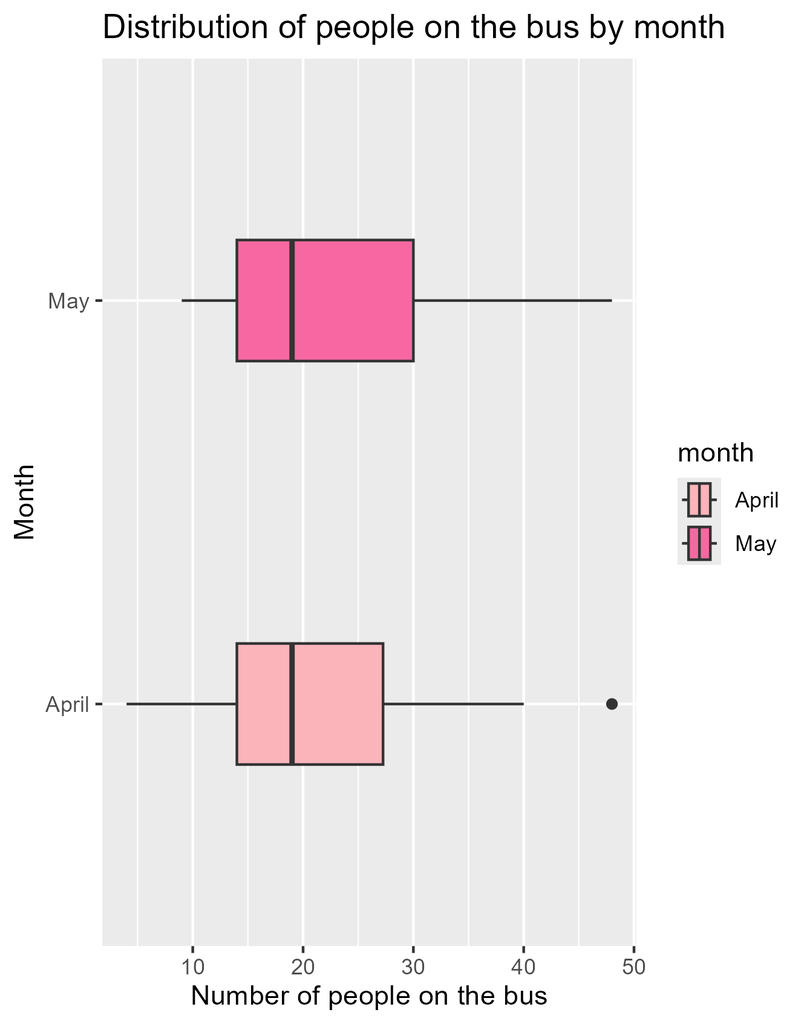

shows the median, lower and upper bound etc